# R для тервера и матстата

## Максимальное правдоподобие

[figure not shown]

# 1. Задача про фонтан

## Задача про фонтан

- Юра приехал в южный город и увидел, что там есть фонтан и он работает
- Теперь все мысли Юры о том, как часто работает этот фонтан

## Задача про фонтан

**Гипотезы:**

1. Фонтан работает раз в году и нам повезло приехать в правильный день
2. Фонтан работает каждые выходные, а мы как раз приехали в выходные
3. Фонтан работает всегда

[figure not shown]

## Задача про фонтан

**Гипотезы:**

1. Фонтан работает раз в году и нам повезло приехать в правильный день $\color{red}{\frac{1}{365}}$
2. Фонтан работает каждые выходные, а мы как раз приехали в выходные $\color{red}{\sim \frac{1}{3}}$
3. Фонтан работает всегда $\color{red}{1}$

[figure not shown]

# 2. Правдоподобие и информация Фишера

**Выборка выпрыгнула из сундука:** $x_1, \ldots, x_n$

[figure not shown]

Мы не знаем, кто выплюнул на нас её из сундука, но можем предположить, что это случайная величина с полотностью $f(x \mid \theta)$. Про $\theta$ ничего не знаем. Видим выборку, хотим оценить.

Запишем правдоподобие наших данных, то есть вероятность пронаблюдать именно эту выборку:

$$L( \theta \mid x_1, \ldots, x_n) = f(x_1, \ldots, x_n \mid \theta) = \prod_{i=1}^n f(x_i \mid \theta) \to \max_{\theta}$$

Для максимизации правдоподобия нам придётся брать производные. Куда приятнее их брать от логарифма:

$$ \ln L( \theta \mid x_1, \ldots, x_n) = \sum_{i=1}^n \ln f(x_i \mid \theta) \to \max_{\theta} $$

Берём производную и приравниваем её к нулю.

$$ \frac{\partial \ln L}{\partial \theta} = \sum_{i=1}^n \frac{\partial \ln f(x_i \mid \theta)}{\partial \theta} = 0 $$

Решив это уравнение мы получим оценку максимального правдоподобия.

```r
x <- rnorm(5)
x
```

1. -0.258773899310492

2. 0.10831577995345

3. -0.906998279353357

4. -1.15404167868822

5. -0.376380937725577

$$ \ln L(\mu, \sigma^2 \mid x) = -\frac{n}{2}\ln(2\pi)-\frac{n}{2}\ln(\sigma^2)-\sum_{i=1}^n\frac{(x_i - \mu)^2}{2\sigma^2} $$

Предположим, что $\sigma = 1$, и нам хочется оценить только $\mu$. Перебьём такую функцию в R.

```r
# mu - оцениваемый параметр
# x - вектор данных

log_lik <- function(mu, x) {
  n <- length(x)
  result <- -n/2*log(2*pi)-n/2*log(1)-sum((x-mu)^2)/(2*1)
  return(result)
}
```

Найдём значение нашей функции в какой-нибудь точке. Какое из значений $\mu$ более правдоподобно?

```r
log_lik(1,x)
log_lik(10,x)
```

-10.8699801433145

-281.660891279432

Теперь посмотрим как правдоподобие выглядит на картинке.

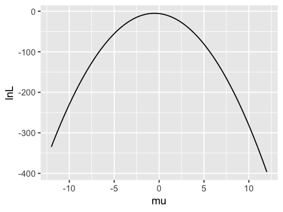

```r
mu  = seq(-12,12,0.01)
lnL = rep(0,length(mu))

for(i in 1:length(lnL)){
    lnL[i] = log_lik(mu[i], x)
}

qplot(mu, lnL, geom='line')
```

Максимум достигается в районе нуля, но не чётко в нуле.

Построим такие же функции для отдельных наблюдений.

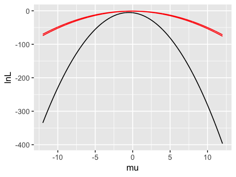

```r
mu  = seq(-12,12,0.01)

lnL = rep(0,length(mu))
lnL1 = rep(0,length(mu))
lnL2 = rep(0,length(mu))

for(i in 1:length(lnL)){
    lnL[i] = log_lik(mu[i], x)
    lnL1[i] = log_lik(mu[i], x[1])
    lnL2[i] = log_lik(mu[i], x[2])
}

df_L = data.frame(mu=mu,lnL = lnL, lnL1 = lnL1, lnL2 = lnL2)

ggplot(df_L, aes(x=mu))+
    geom_line(aes(y=lnL))+
    geom_line(aes(y=lnL1),color='red')+
    geom_line(aes(y=lnL2),color='red')
```

```r
lnL = rep(0,length(mu))
lnL1 = rep(0,length(mu))
lnL2 = rep(0,length(mu))
lnL3 = rep(0,length(mu))
lnL4 = rep(0,length(mu))
lnL5 = rep(0,length(mu))

for(i in 1:length(lnL)){
    lnL[i] = log_lik(mu[i], x)
    lnL1[i] = log_lik(mu[i], x[1])
    lnL2[i] = log_lik(mu[i], x[1:2])
    lnL3[i] = log_lik(mu[i], x[1:3])
    lnL4[i] = log_lik(mu[i], x[1:4])
}

df_L = data.frame(mu=mu,lnL = lnL, lnL1 = lnL1, lnL2 = lnL2,
                  lnL3 = lnL3,lnL4 = lnL4)
```

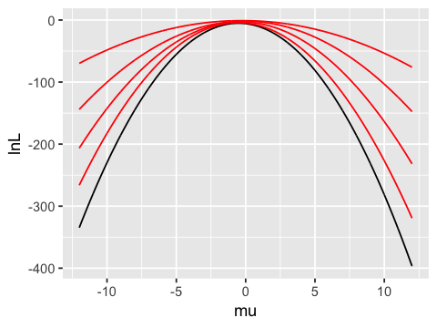

```r
ggplot(df_L, aes(x=mu))+
    geom_line(aes(y=lnL))+
    geom_line(aes(y=lnL1),color='red')+
    geom_line(aes(y=lnL2),color='red')+
    geom_line(aes(y=lnL3),color='red')+
    geom_line(aes(y=lnL4),color='red')
```

Что отвечает за выпуклость функции? Правильно! Вторая производная. Именно её, взятую со знаком минус, интерпретируют как наблюдённую информацию.

$$ I_o(\theta) = - \left( \frac{\partial^2 \ln L}{\partial \theta^2} \right) $$

Почему со знаком минус? Потому что у нас максимум, в точке максимума вторая производная отрицательна. А информация должна быть положительной. Если параметр векторный, то в этом случае наблюдённая информация представляется наблюдённой информационной матрицей:

$$ I_o(\theta) = - \left( \frac{\partial^2 \ln L}{\partial \theta_i \partial \theta_j} \right) = - H $$

Математическое ожидание этой матрицы по распределению $x$ называется информационной матрицей Фишера.

$$ I(\theta) = - E\left( \frac{\partial^2 \ln L}{\partial \theta_i \partial \theta_j} \right) = -E(H) $$

# 3. Задача про M&M-сины

[figure not shown]

```r
# задаем оценку информационной матрицы руками
# Первый способ - подставим в -H оценки параметров:
x1 = 46
x2 = 44
x3 = 237
n = x1 + x2 + x3

hat.I <- matrix(c(x1/0.14^2+237/0.73^2, 237/0.73^2,
                  237/0.73^2, x2/0.14^2+237/0.73^2),nrow=2)
hat.I
```

| 2791.6751 | 444.7363 |
| --- | --- |
| 444.7363 | 2689.6343 |

```r
# считаем обратную --- это будет оценка ковариационной матрицы ошибок
hat.Var <- solve(hat.I)
hat.Var
```

| 3.678990e-04 | -6.083283e-05 |
| --- | --- |
| -6.083283e-05 | 3.818566e-04 |

```r
# Второй способ - подставим в -E(H) оценки параметров:
hat.I <- matrix(c(n/0.14 + n/0.73, n/0.73,
                  n/0.73, n/0.14 + n/0.73),nrow=2)
hat.I
```

| 2783.6595 | 447.9452 |
| --- | --- |
| 447.9452 | 2783.6595 |

```r
# считаем обратную --- это будет оценка ковариационной матрицы ошибок
hat.Var <- solve(hat.I)
hat.Var
```

| 3.687892e-04 | -5.934538e-05 |
| --- | --- |
| -5.934538e-05 | 3.687892e-04 |

**Вопрос:** являются ли оценки зависимыми?

# 4. Пакет maxLik

```r
# install.packages('maxLik')  # если пакет не установлен
library('maxLik') # пакет для метода макс. правдоподобия

# Логарифмическое правдоподобие
lnL <- function(p,X) {
    ans <- X[1]*log(p[1])+X[2]*log(p[2])+ (X[3])*log(1-p[1]-p[2])
  return(ans)
}

# Задаём точку для старта, а также выборку, которая пойдёт на вход lnL
res <- maxLik(lnL, start=c(0.1,0.1), X=c(44, 46, 237))
```

[output not shown]

```r
summary(res) # краткий отчет о результатах оценивания

# первый столбик --- сами оценки по методу максимального правдоподобия
# второй столбик --- оценки стандартных ошибок
# т.е. корни из диагональных элементов оценённой ковариационной матрицы
# в третьем и четвёртом столбиках проверятся гипотеза о равенстве этих параметров нулю,
# но об этом позже :)
```

```
--------------------------------------------
Maximum Likelihood estimation
Newton-Raphson maximisation, 4 iterations
Return code 1: gradient close to zero
Log-Likelihood: -254.7649
2  free parameters
Estimates:
     Estimate Std. error t value  Pr(> t)
[1,]  0.13456    0.01887   7.130 1.00e-12 ***
[2,]  0.14067    0.01923   7.316 2.55e-13 ***
---
Signif. codes:  0 ‘***’ 0.001 ‘**’ 0.01 ‘*’ 0.05 ‘.’ 0.1 ‘ ’ 1
--------------------------------------------
```

```r
# можно вытащить протокол из summary в табличку
result_table = summary(res)
result_table$estimate
```

| Estimate | Std. error | t value | Pr(> t) |
| --- | --- | --- | --- |
| 0.1345566 | 0.01887130 | 7.130222 | 1.002075e-12 |
| 0.1406728 | 0.01922697 | 7.316428 | 2.546578e-13 |

```r
# можно вытащить ещё чего-нибудь эдакого
result_table$loglik
```

-254.764874303474

```r
p = res$estimate  # оценки
p
```

1. 0.134556574942643

2. 0.140672782905346

```r
res$hessian # оценка матрицы Гессе
```

| -2881.3361 | -451.1946 |
| --- | --- |
| -451.1946 | -2775.7210 |

```r
p_var = solve(-1*res$hessian)  # оценка ковариационной матрицы оценок
p_var
```

| 3.561261e-04 | -5.788845e-05 |
| --- | --- |
| -5.788845e-05 | 3.696765e-04 |

**Упражнение:** Давайте же построим асимптотический доверительный интервал для $\hat p_1$:

```r
alpha = 0.05
z_alpha = qnorm(1 - alpha/2)

p[1] - z_alpha*sqrt(p_var[1,1])
p[1] + z_alpha*sqrt(p_var[1,1])
```

0.0975694998000463

0.17154365008524

**Упражнение:** как построить доверительный интервал для разницы $\hat p_1 - \hat p_2$?

$$ Var( \hat p_1 - \hat p_2) = Var(\hat p_1) + Var(\hat p_2) + 2 Cov(\hat p_1, -\hat p_2) = Var(\hat p_1) + Var(\hat p_2) - 2 Cov(\hat p_1, \hat p_2) $$

```r
diff_std = sqrt(p_var[1,1] + p_var[2,2] - 2*p_var[1,2])
diff = p[1] - p[2]

diff - z_alpha*diff_std
diff + z_alpha*diff_std
```

-0.062974744358241

0.0507423284328344

Ноль попал в доверительный интервал. Что это, означает?

# Что мы сегодня осознали?

- Метод максимального правдоподобия - что я вижу, то и есть на самом деле.
- Производные содержут в себе информацию и именно они используются для её передачи в современной статистике и машинном обучении. Например, вторая производная функции правдоподобия говорит о том, насколько ярко выражен пик правдоподобия.
- Информация Фишера говорит о острие пика, это усреднённая по выборке вторая производная, взятая со знаком минус (потому что мы максимизируем правдоподобие, в оптимуме вторая производная отрицательна, надо это компенсировать ещё одним минусом).